# Brick and Mortar Other Questions

John Cornelison

2024-03-11

The following tables are for the remaining questions, and it is filtered down to only brick and mortar shelters. There are 386 responses

## General Summary

#### Q6 Intakes, Live Release Rate

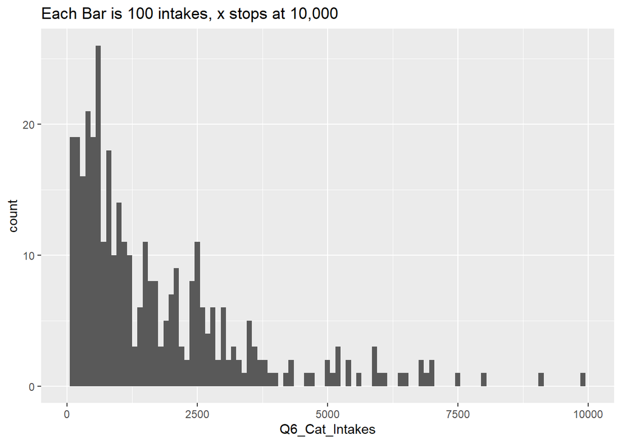

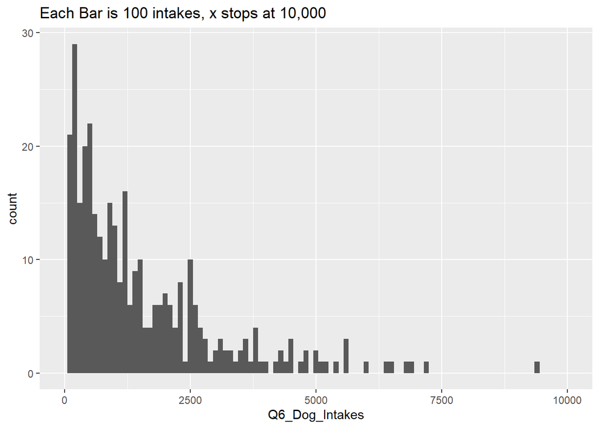

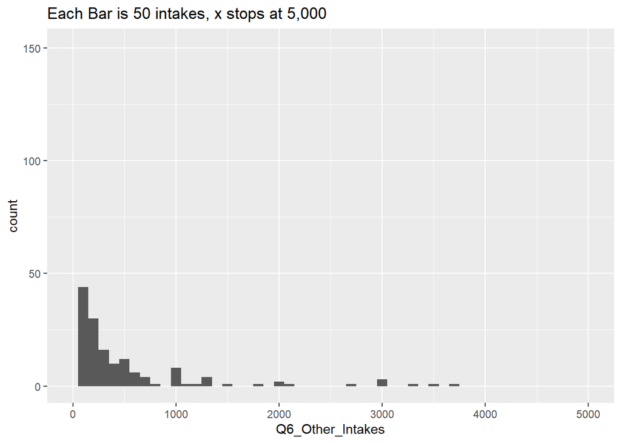

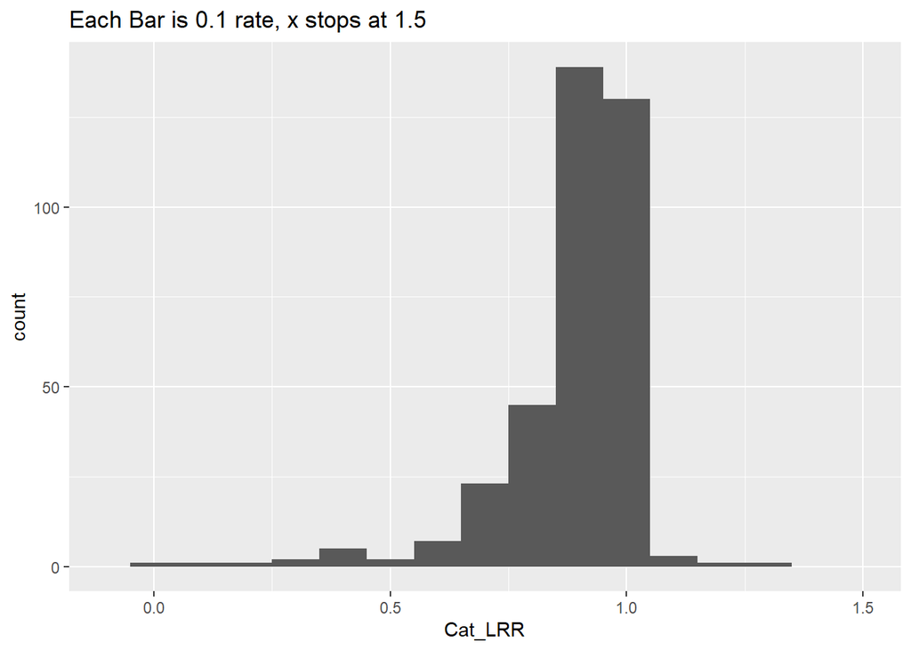

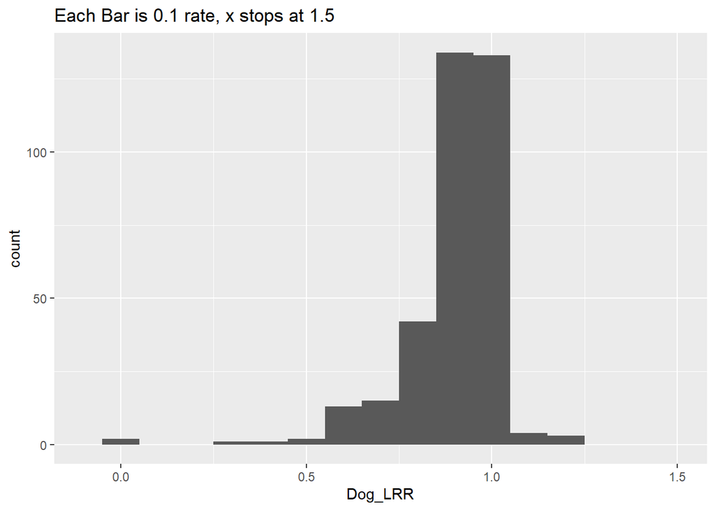

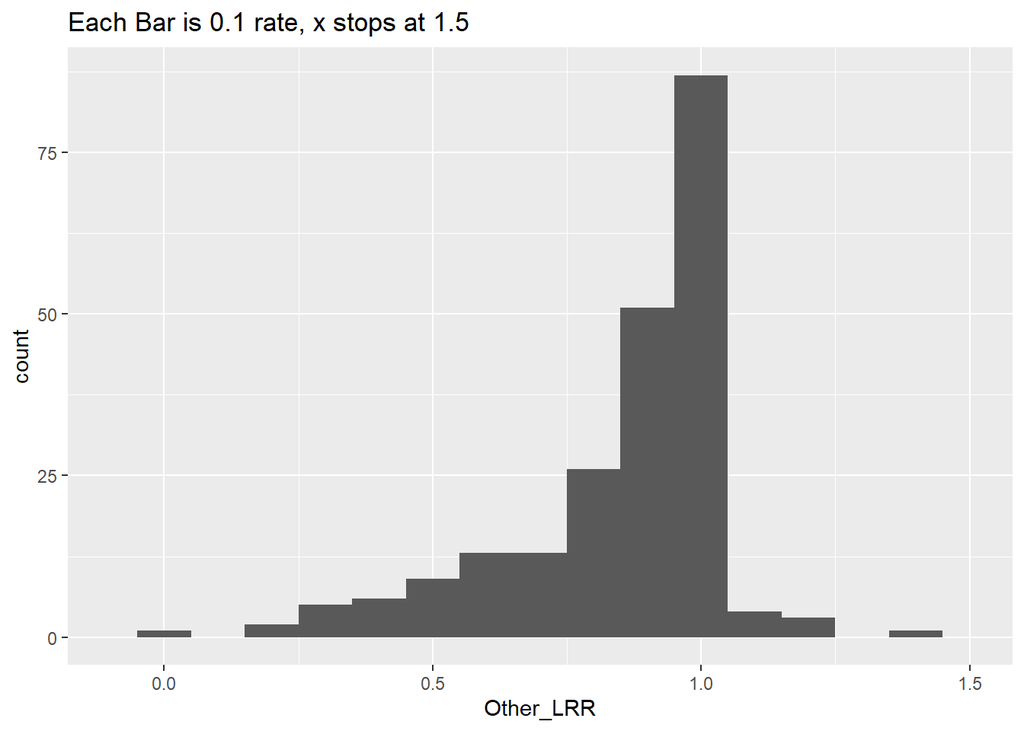

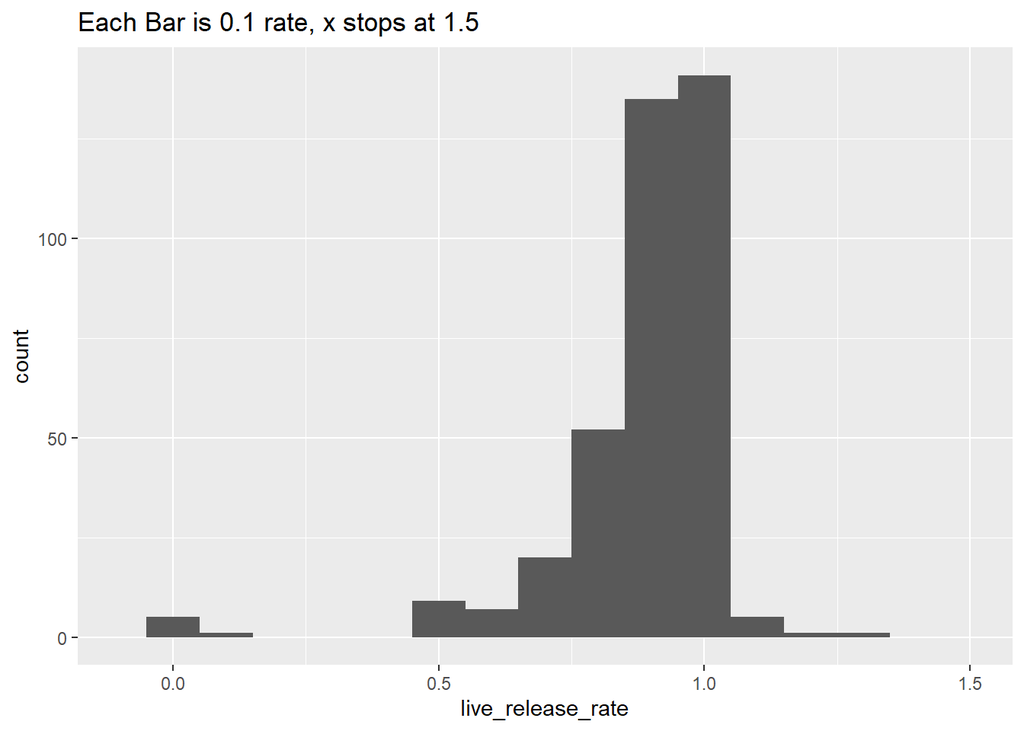

#### Q7 Average Length of Stay

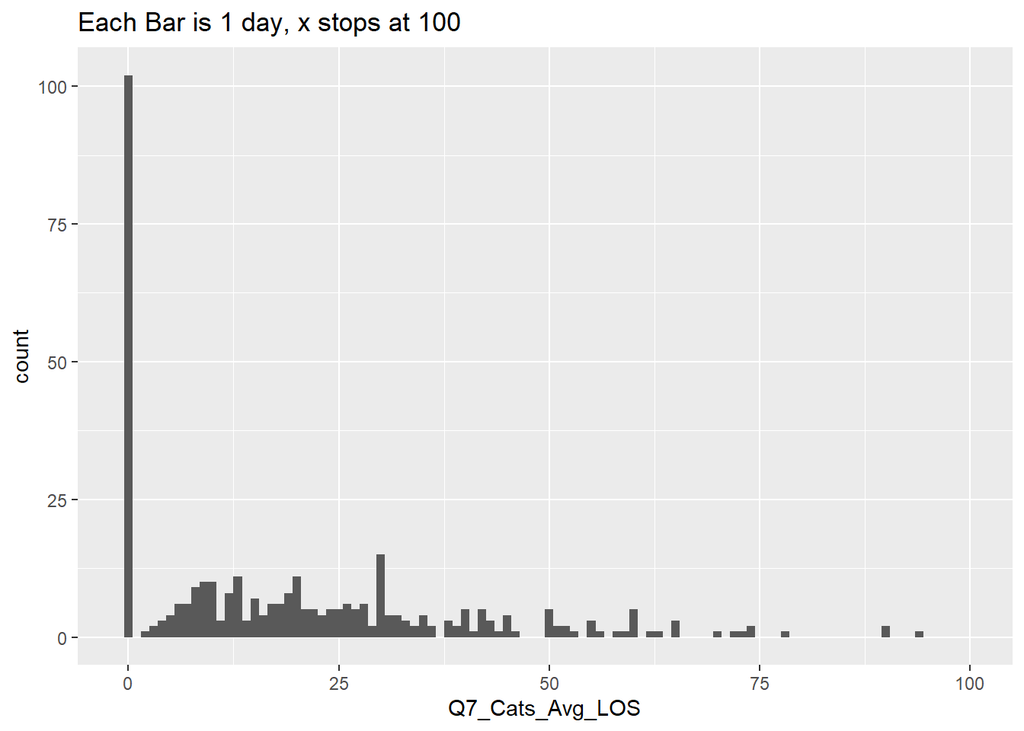

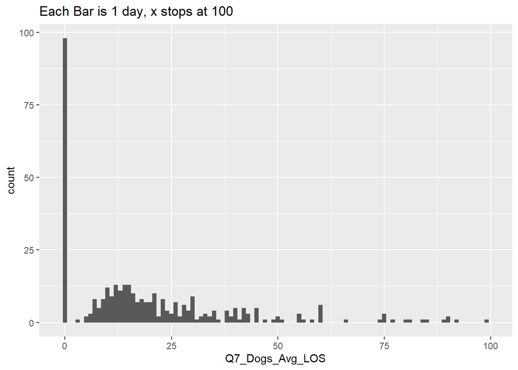

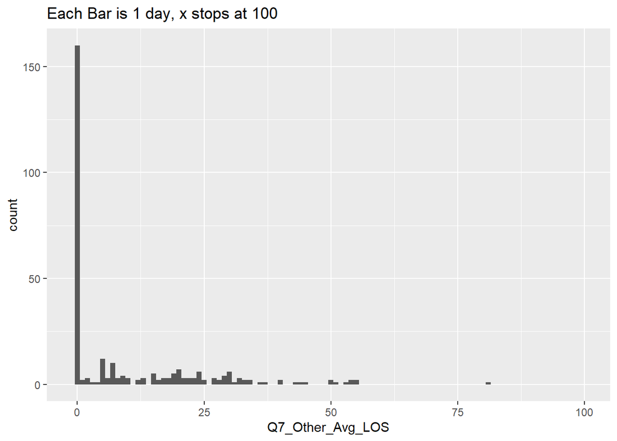

#### Q9 Current Vet Hours

Only asked to those who answered Yes to having at least one vet on staff

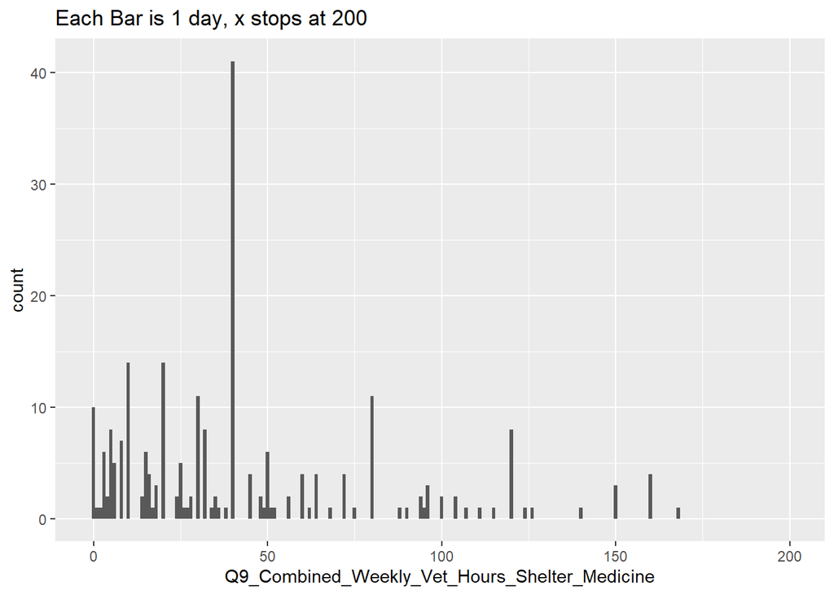

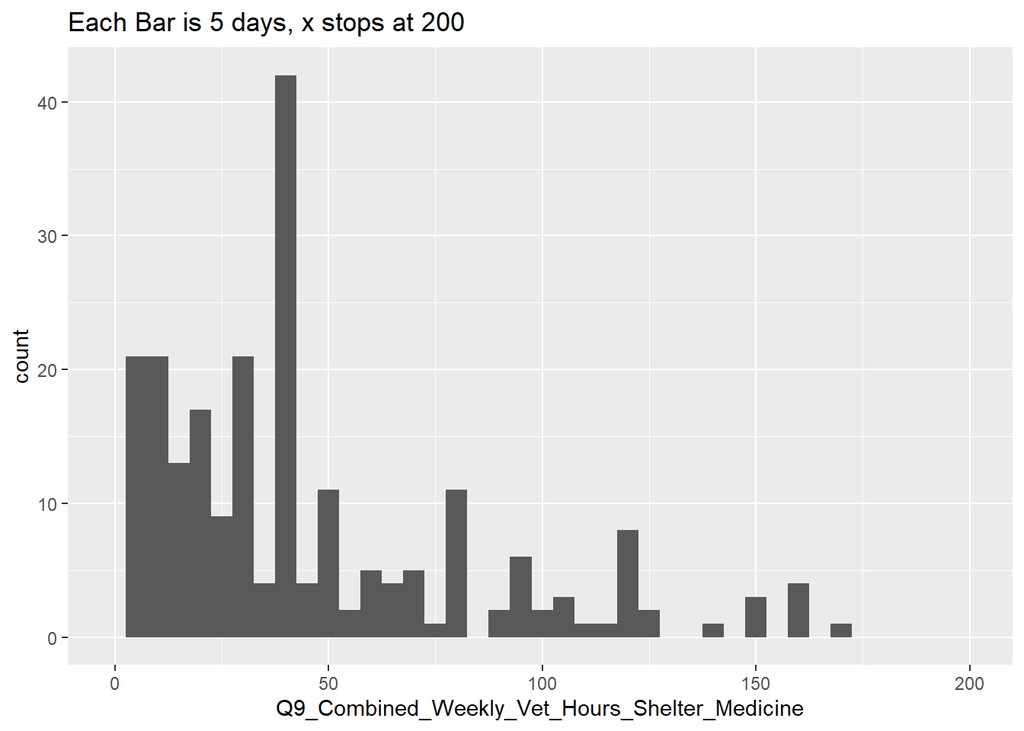

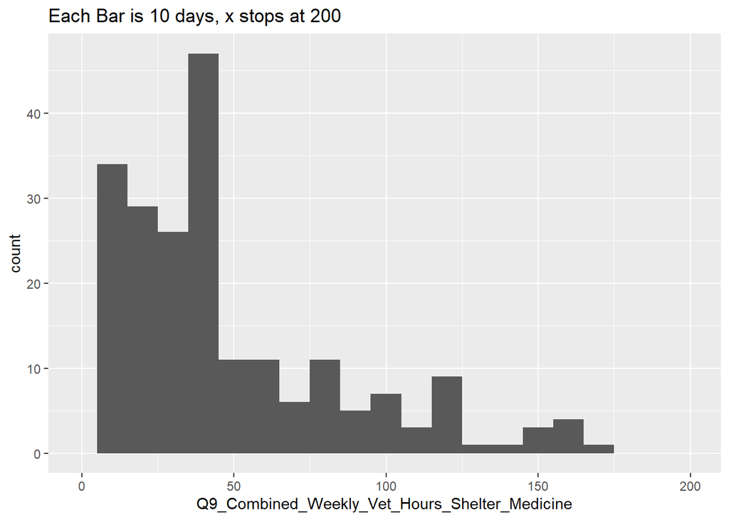

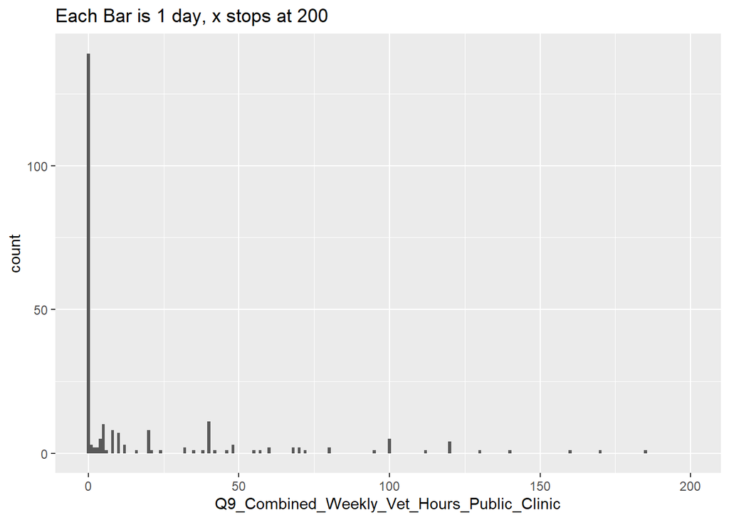

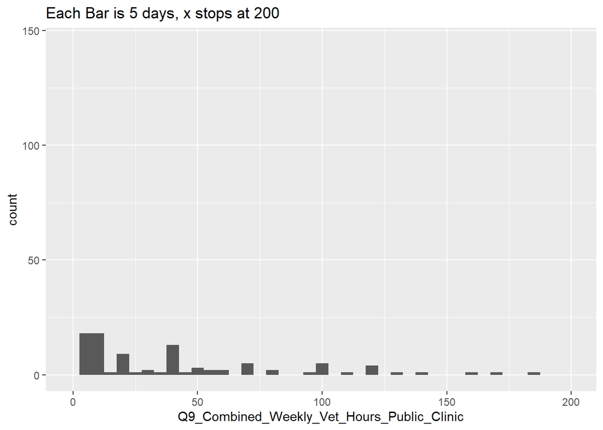

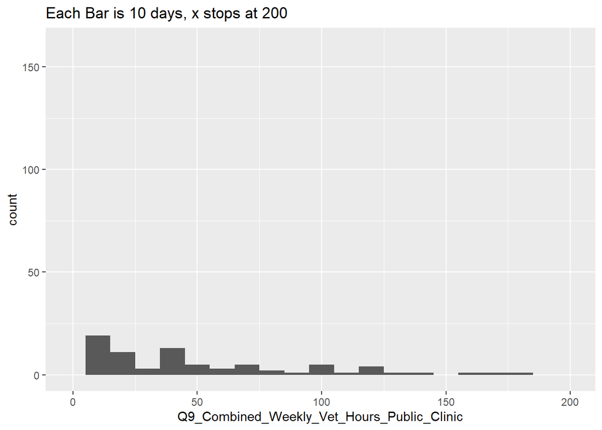

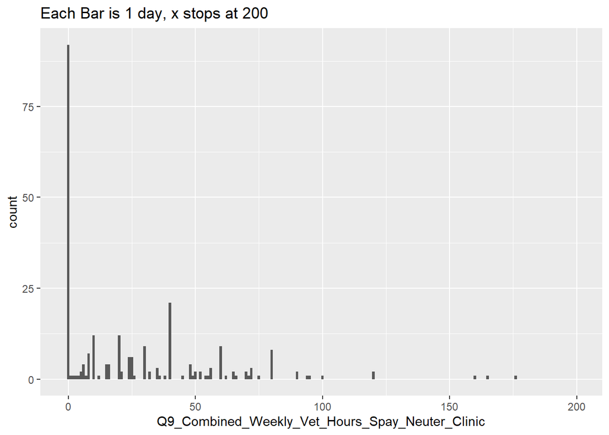

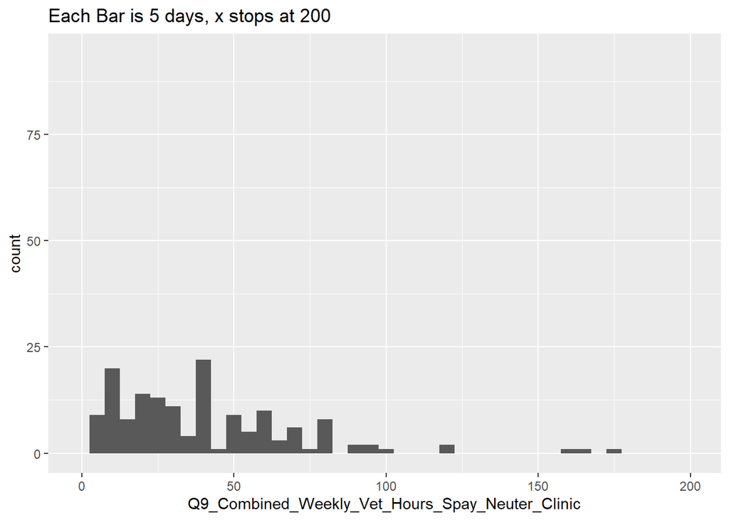

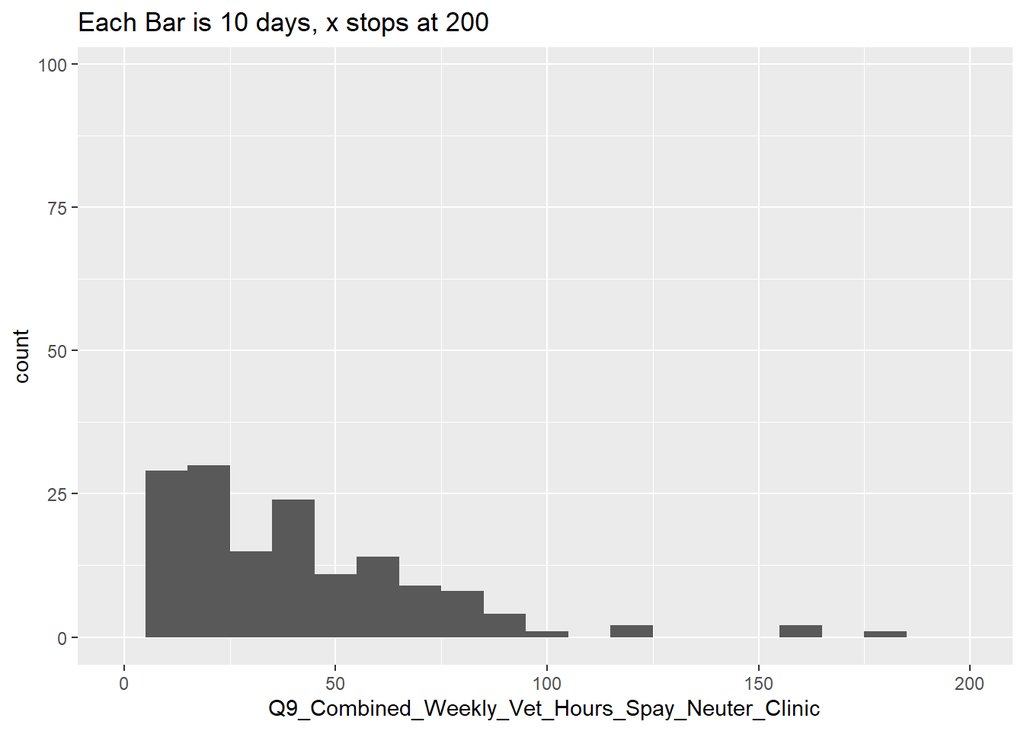

#### Q10 Average Vet Annual Salary

Only asked to those who answered Yes to having at least one vet on staff. There were several people who responded unknown.

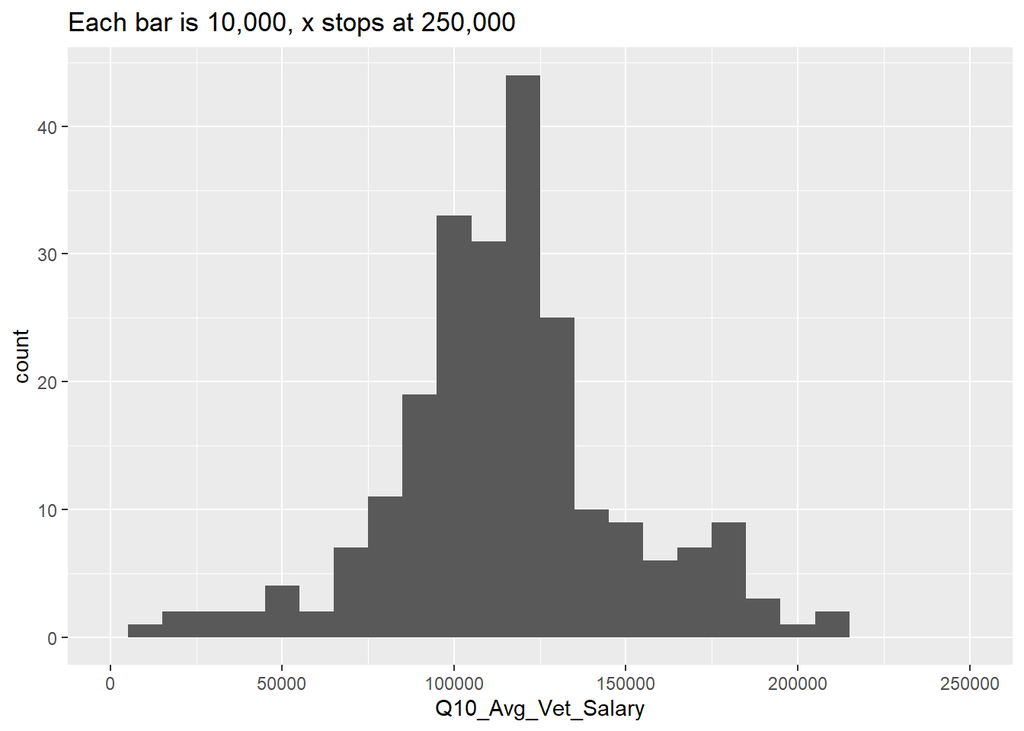

#### Q11 Reasons for Not having a Vet

Only those how responded no to having a vet were asked this question

|  | Q11_No_Vet_Reason_Budget | Count | Percent |
| --- | --- | --- | --- |
| 1 | Yes | 73 | 52.90% |
| 2 |  | 138 |  |

|  | Q11_No_Vet_Reason_Inability_To_Recruit | Count | Percent |
| --- | --- | --- | --- |
| 1 | Yes | 41 | 29.71% |
| 2 |  | 138 |  |

|  | Q11_No_Vet_Reason_Use_Local_Clinic | Count | Percent |
| --- | --- | --- | --- |
| 1 | Yes | 97 | 70.29% |
| 2 |  | 138 |  |

|  | Q11_No_Vet_Reason_Use_Vet_Contractors | Count | Percent |
| --- | --- | --- | --- |
| 1 | Yes | 39 | 28.26% |
| 2 |  | 138 |  |

|  | Q11_No_Vet_Reason_No_Need_For_Vet | Count | Percent |
| --- | --- | --- | --- |
| 1 | Yes | 3 | 2.17% |
| 2 |  | 138 |  |

|  | Q11_No_Vet_Reason_Other | Count | Percent |
| --- | --- | --- | --- |
| 1 | Yes | 29 | 21.01% |
| 2 |  | 138 |  |

#### Q12 Currently Recruiting On-staff Vet

|  | Q12_Org_Recruiting_Vet | Count | Percent |
| --- | --- | --- | --- |
| 1 | No | 262 | 67.88% |
| 2 | Yes | 124 | 32.12% |
| 3 |  | 386 |  |

#### Q13 Vet Care Hours Per Week Looking to Fill

Only those who answered yes to question 12 were asked this question

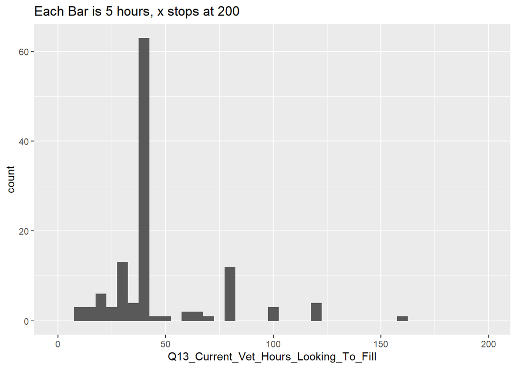

#### Q14 Annual Vet Salary Offered

Only asked those who answered yes to question 12

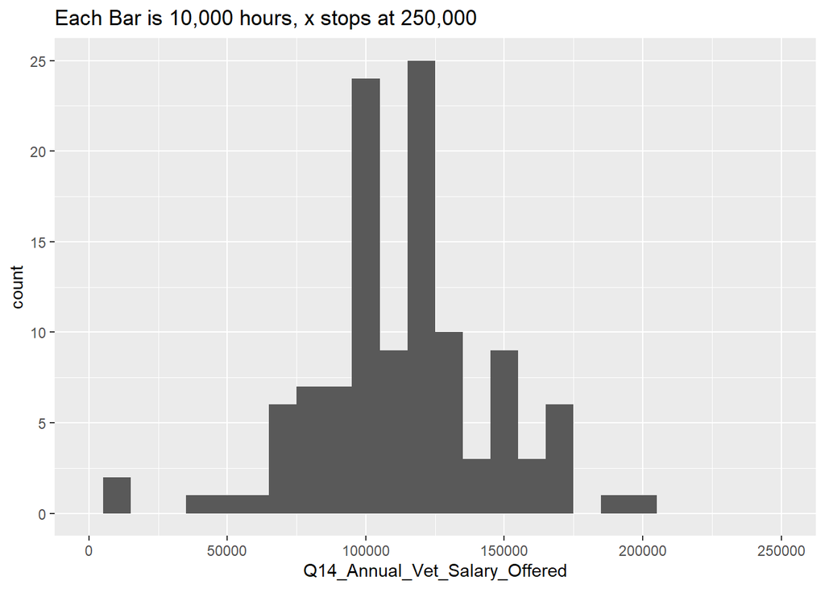

#### Q15 Benefits Currently Offered

Only those who answered yes to question 8 or 12 were asked this question

|  | Q15_Benefits_Annual_Cost_Of_Living_Raise | Count | Percent |
| --- | --- | --- | --- |
| 1 | Yes | 132 | 49.81% |
| 2 |  | 265 |  |

|  | Q15_Benefits_Assigned_Mentor | Count | Percent |
| --- | --- | --- | --- |
| 1 | Yes | 42 | 15.85% |
| 2 |  | 265 |  |

|  | Q15_Benefits_Conference_Attendance_Registration_And_Travel_Expenses | Count | Percent |
| --- | --- | --- | --- |
| 1 | Yes | 191 | 72.08% |
| 2 |  | 265 |  |

|  | Q15_Benefits_Employee_Assistance_Program | Count | Percent |
| --- | --- | --- | --- |
| 1 | Yes | 173 | 65.28% |
| 2 |  | 265 |  |

|  | Q15_Benefits_Flexible_Work_Schedule | Count | Percent |
| --- | --- | --- | --- |
| 1 | Yes | 154 | 58.11% |
| 2 |  | 265 |  |

|  | Q15_Benefits_Health_Insurance | Count | Percent |
| --- | --- | --- | --- |
| 1 | Yes | 218 | 82.26% |
| 2 |  | 265 |  |

|  | Q15_Benefits_Housing_Stipend | Count | Percent |
| --- | --- | --- | --- |
| 1 | Yes | 1 | 0.38% |
| 2 |  | 265 |  |

|  | Q15_Benefits_Merit_Based_Raise | Count | Percent |
| --- | --- | --- | --- |
| 1 | Yes | 119 | 44.91% |
| 2 |  | 265 |  |

|  | Q15_Benefits_Paying_For_Annual_Continuing_Education_Credits | Count | Percent |
| --- | --- | --- | --- |
| 1 | Yes | 199 | 75.09% |
| 2 |  | 265 |  |

|  | Q15_Benefits_Paying_Professional_Association_Dues | Count | Percent |
| --- | --- | --- | --- |
| 1 | Yes | 198 | 74.72% |
| 2 |  | 265 |  |

|  | Q15_Benefits_PTO | Count | Percent |
| --- | --- | --- | --- |
| 1 | Yes | 238 | 89.81% |
| 2 |  | 265 |  |

|  | Q15_Benefits_Relocation_Assistance | Count | Percent |
| --- | --- | --- | --- |
| 1 | Yes | 54 | 20.38% |
| 2 |  | 265 |  |

|  | Q15_Benefits_Retirement_Payments | Count | Percent |
| --- | --- | --- | --- |
| 1 | Yes | 189 | 71.32% |
| 2 |  | 265 |  |

|  | Q15_Benefits_Scheduled_Rotations | Count | Percent |
| --- | --- | --- | --- |
| 1 | Yes | 22 | 8.30% |
| 2 |  | 265 |  |

|  | Q15_Benefits_Signing_Bonus | Count | Percent |
| --- | --- | --- | --- |
| 1 | Yes | 49 | 18.49% |
| 2 |  | 265 |  |

|  | Q15_Benefits_Student_Loan_Repayment | Count | Percent |
| --- | --- | --- | --- |
| 1 | Yes | 40 | 15.09% |
| 2 |  | 265 |  |

|  | Q15_Benefits_Other | Count | Percent |
| --- | --- | --- | --- |
| 1 | Yes | 45 | 16.98% |
| 2 |  | 265 |  |

#### Q16 Factors that Make it Difficult to Recruit Vets

|  | Q16_Stressful_Nature_Work. | Count | Percent |
| --- | --- | --- | --- |
| 1 | Neither | 82 | 21.64% |
| 2 | Somewhat agree | 153 | 40.37% |
| 3 | Somewhat disagree | 27 | 7.12% |
| 4 | Strongly agree | 98 | 25.86% |
| 5 | Strongly disagree | 19 | 5.01% |
| 6 |  | 379 |  |

|  | Q16_Long_Work_Hours | Count | Percent |
| --- | --- | --- | --- |
| 1 | Neither | 116 | 30.53% |
| 2 | Somewhat agree | 96 | 25.26% |
| 3 | Somewhat disagree | 77 | 20.26% |
| 4 | Strongly agree | 32 | 8.42% |
| 5 | Strongly disagree | 59 | 15.53% |
| 6 |  | 380 |  |

|  | Q16_Challenging_Working_Relationships_With_Organization_Leadership | Count | Percent |
| --- | --- | --- | --- |
| 1 | Neither | 116 | 30.61% |
| 2 | Somewhat agree | 61 | 16.09% |
| 3 | Somewhat disagree | 66 | 17.41% |
| 4 | Strongly agree | 25 | 6.60% |
| 5 | Strongly disagree | 111 | 29.29% |
| 6 |  | 379 |  |

|  | Q16_Private_Practice_Offers_Higher_Salary | Count | Percent |
| --- | --- | --- | --- |
| 1 | Neither | 48 | 12.60% |
| 2 | Somewhat agree | 84 | 22.05% |
| 3 | Somewhat disagree | 13 | 3.41% |
| 4 | Strongly agree | 227 | 59.58% |
| 5 | Strongly disagree | 9 | 2.36% |
| 6 |  | 381 |  |

|  | Q16_Lack_of_Training_in_Shelter_Medicine | Count | Percent |
| --- | --- | --- | --- |
| 1 | Neither | 91 | 24.07% |
| 2 | Somewhat agree | 128 | 33.86% |
| 3 | Somewhat disagree | 49 | 12.96% |
| 4 | Strongly agree | 67 | 17.72% |
| 5 | Strongly disagree | 43 | 11.38% |
| 6 |  | 378 |  |

|  | Q16_Geographic_Area_Not_Desirable_For_Residence | Count | Percent |
| --- | --- | --- | --- |
| 1 | Neither | 99 | 26.05% |
| 2 | Somewhat agree | 76 | 20.00% |
| 3 | Somewhat disagree | 65 | 17.11% |
| 4 | Strongly agree | 56 | 14.74% |
| 5 | Strongly disagree | 84 | 22.11% |
| 6 |  | 380 |  |

|  | Q16_No_Flexible_Work_Schedule | Count | Percent |
| --- | --- | --- | --- |
| 1 | Neither | 115 | 30.42% |
| 2 | Somewhat agree | 66 | 17.46% |
| 3 | Somewhat disagree | 77 | 20.37% |
| 4 | Strongly agree | 22 | 5.82% |
| 5 | Strongly disagree | 98 | 25.93% |
| 6 |  | 378 |  |

|  | Q16_Lack_Of_Support_Staff | Count | Percent |
| --- | --- | --- | --- |
| 1 | Neither | 102 | 26.77% |
| 2 | Somewhat agree | 104 | 27.30% |
| 3 | Somewhat disagree | 72 | 18.90% |
| 4 | Strongly agree | 53 | 13.91% |
| 5 | Strongly disagree | 50 | 13.12% |
| 6 |  | 381 |  |

|  | Q16_Lack_Of_Mentorship_From_Senior_Vet | Count | Percent |
| --- | --- | --- | --- |
| 1 | Neither | 157 | 41.53% |
| 2 | Somewhat agree | 83 | 21.96% |
| 3 | Somewhat disagree | 51 | 13.49% |
| 4 | Strongly agree | 25 | 6.61% |
| 5 | Strongly disagree | 62 | 16.40% |
| 6 |  | 378 |  |

|  | Q16_Frustration_Of_Reporting_To_Non-Vet | Count | Percent |
| --- | --- | --- | --- |
| 1 | Neither | 146 | 38.62% |
| 2 | Somewhat agree | 65 | 17.20% |
| 3 | Somewhat disagree | 67 | 17.72% |
| 4 | Strongly agree | 20 | 5.29% |
| 5 | Strongly disagree | 80 | 21.16% |
| 6 |  | 378 |  |

|  | Q16_Mandate_To_Practice_Medicine_Within_Budget_Or_Policy_Constraints | Count | Percent |
| --- | --- | --- | --- |
| 1 | Neither | 104 | 27.37% |
| 2 | Somewhat agree | 123 | 32.37% |
| 3 | Somewhat disagree | 62 | 16.32% |
| 4 | Strongly agree | 36 | 9.47% |
| 5 | Strongly disagree | 55 | 14.47% |
| 6 |  | 380 |  |

|  | Q16_On-Call_After_Hours | Count | Percent |
| --- | --- | --- | --- |
| 1 | Neither | 125 | 32.89% |
| 2 | Somewhat agree | 90 | 23.68% |
| 3 | Somewhat disagree | 49 | 12.89% |
| 4 | Strongly agree | 40 | 10.53% |
| 5 | Strongly disagree | 76 | 20.00% |
| 6 |  | 380 |  |

|  | Q16_Stress_Of_Carrying_The_Professional_Lic_For_The_Org_To_Use_Schedule_II_Narcotics | Count | Percent |
| --- | --- | --- | --- |
| 1 | Neither | 138 | 36.41% |
| 2 | Somewhat agree | 71 | 18.73% |
| 3 | Somewhat disagree | 56 | 14.78% |
| 4 | Strongly agree | 26 | 6.86% |
| 5 | Strongly disagree | 88 | 23.22% |
| 6 |  | 379 |  |

|  | Q16_Burn-Out_And_Compassion_Fatigue | Count | Percent |
| --- | --- | --- | --- |
| 1 | Neither | 86 | 22.57% |
| 2 | Somewhat agree | 150 | 39.37% |
| 3 | Somewhat disagree | 45 | 11.81% |
| 4 | Strongly agree | 85 | 22.31% |
| 5 | Strongly disagree | 15 | 3.94% |
| 6 |  | 381 |  |

|  | Q16_Being_Only_Vet_On_Staff | Count | Percent |
| --- | --- | --- | --- |
| 1 | Neither | 122 | 32.28% |
| 2 | Somewhat agree | 85 | 22.49% |
| 3 | Somewhat disagree | 34 | 8.99% |
| 4 | Strongly agree | 42 | 11.11% |
| 5 | Strongly disagree | 95 | 25.13% |
| 6 |  | 378 |  |

#### Q18 Number of Vet Techs Employed

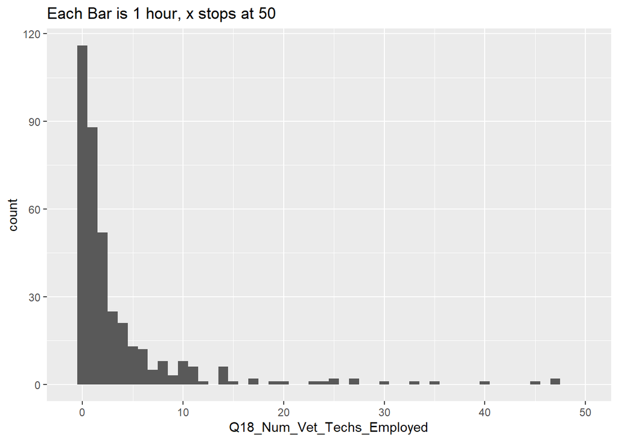

#### Q19 Number of Unlicensed Veterinary Assistants

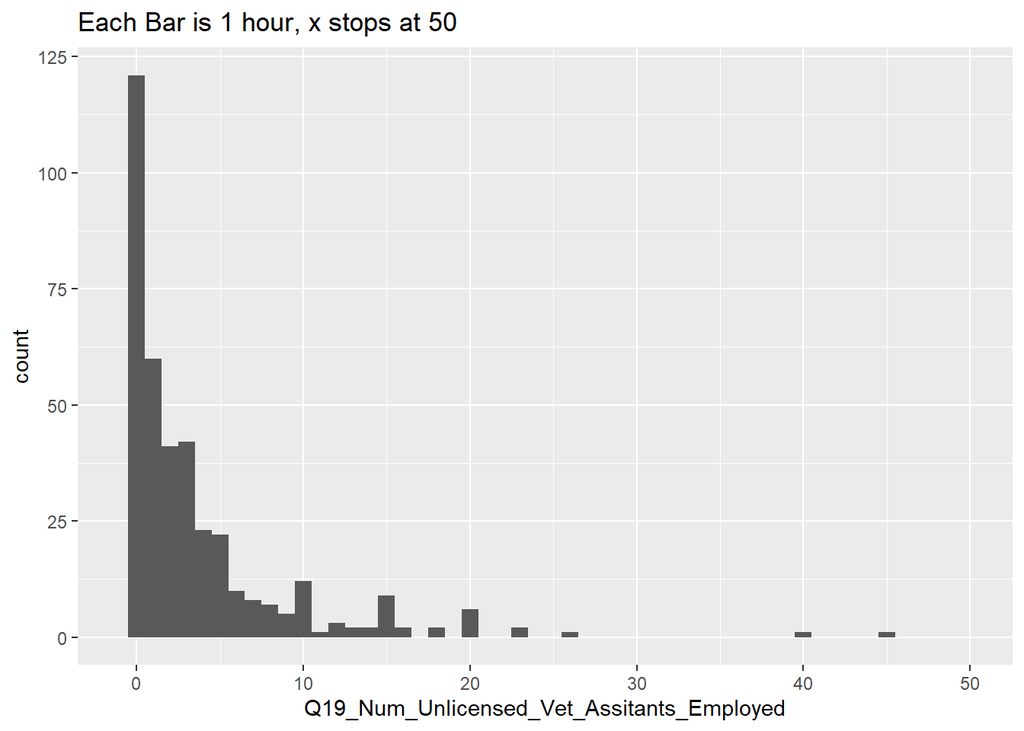

#### Q20 Vet Care Provided

|  | Q20_Provides_Spay-Neuter_For_Org_Animals_By_Own_Vet_Staff_Or_From_A_Local_Vet | Count | Percent |
| --- | --- | --- | --- |
| 1 | Yes | 351 | 91.41% |
| 2 |  | 384 |  |

|  | Q20_Provides_Spay-Neuter_For_Publicly_Owned_Animals | Count | Percent |
| --- | --- | --- | --- |
| 1 | Yes | 209 | 54.43% |
| 2 |  | 384 |  |

|  | Q20_Provides_Owner_Requested_Euthanasia_For_Publicly_Owned_Animals | Count | Percent |
| --- | --- | --- | --- |
| 1 | Yes | 211 | 54.95% |
| 2 |  | 384 |  |

|  | Q20_Provides_Vet_Care_For_Our_Org_Animals | Count | Percent |
| --- | --- | --- | --- |
| 1 | Yes | 359 | 93.49% |
| 2 |  | 384 |  |

|  | Q20_Provides_Non-Spay/Neuter_Vet_Care_For_Publicly_Owned_Animals | Count | Percent |
| --- | --- | --- | --- |
| 1 | Yes | 160 | 41.67% |
| 2 |  | 384 |  |

|  | Q20_Provides_Community_Vaccination_Clinics | Count | Percent |
| --- | --- | --- | --- |
| 1 | Yes | 227 | 59.11% |
| 2 |  | 384 |  |

|  | Q20_Provides_Health_Certificates_For_Transport | Count | Percent |
| --- | --- | --- | --- |
| 1 | Yes | 154 | 40.10% |
| 2 |  | 384 |  |

|  | Q20_Provides_Necropsies_And/Or_Forensic_Work_For_Law_Enforcement | Count | Percent |
| --- | --- | --- | --- |
| 1 | Yes | 115 | 29.95% |
| 2 |  | 384 |  |

|  | Q20_Provides_Specimen_Collection_And_Testing_For_Rabies | Count | Percent |
| --- | --- | --- | --- |
| 1 | Yes | 168 | 43.75% |
| 2 |  | 384 |  |

#### Q34 Access to Vet Care Change Since Pre-Pandemic

|  | Q34_Compared to pre-pandemic access to vet care change | Count | Percent |
| --- | --- | --- | --- |
| 1 | Easier | 28 | 7.27% |
| 2 | More difficult | 189 | 49.09% |
| 3 | No difference | 137 | 35.58% |
| 4 | Not sure | 31 | 8.05% |
| 5 |  | 385 |  |

#### Q35 Vet Workforce Shortage Solutions

|  | Q35_Significant impact to address workforce shortage_Increased utilization of veterinary technicians | Count | Percent |
| --- | --- | --- | --- |
| 1 | Yes | 300 | 78.95% |
| 2 |  | 380 |  |

|  | Q35_Significant impact to address workforce shortage_Creation of midlevel practitioner similar to a physician’s assistant in human medicine | Count | Percent |
| --- | --- | --- | --- |
| 1 | Yes | 289 | 76.05% |
| 2 |  | 380 |  |

|  | Q35_Significant impact to address workforce shortage_Increased scope of practice for existing veterinary technicians without specialist certification | Count | Percent |
| --- | --- | --- | --- |
| 1 | Yes | 229 | 60.26% |
| 2 |  | 380 |  |

|  | Q35_Significant impact to address workforce shortage_Other | Count | Percent |
| --- | --- | --- | --- |
| 1 | Yes | 65 | 17.11% |
| 2 |  | 380 |  |

#### Vet Hours to Animals Ratio

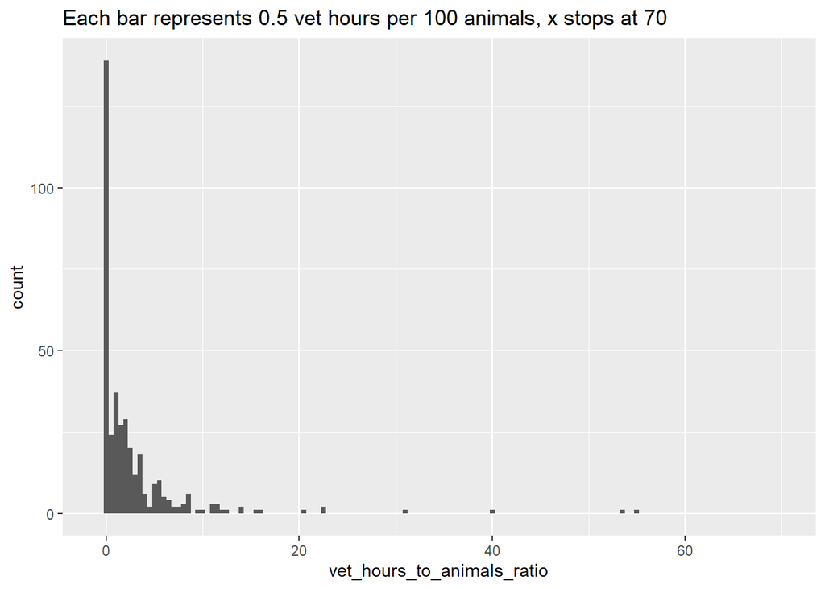

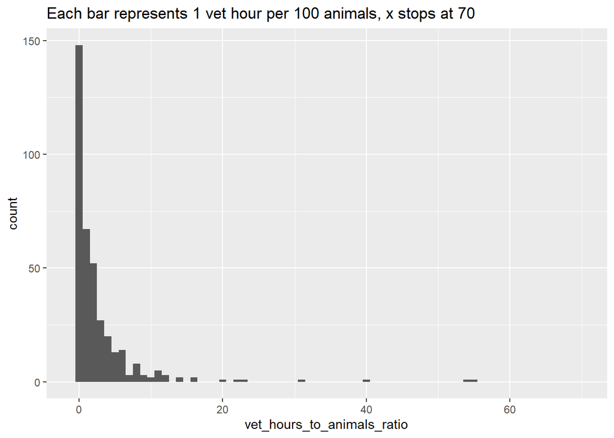

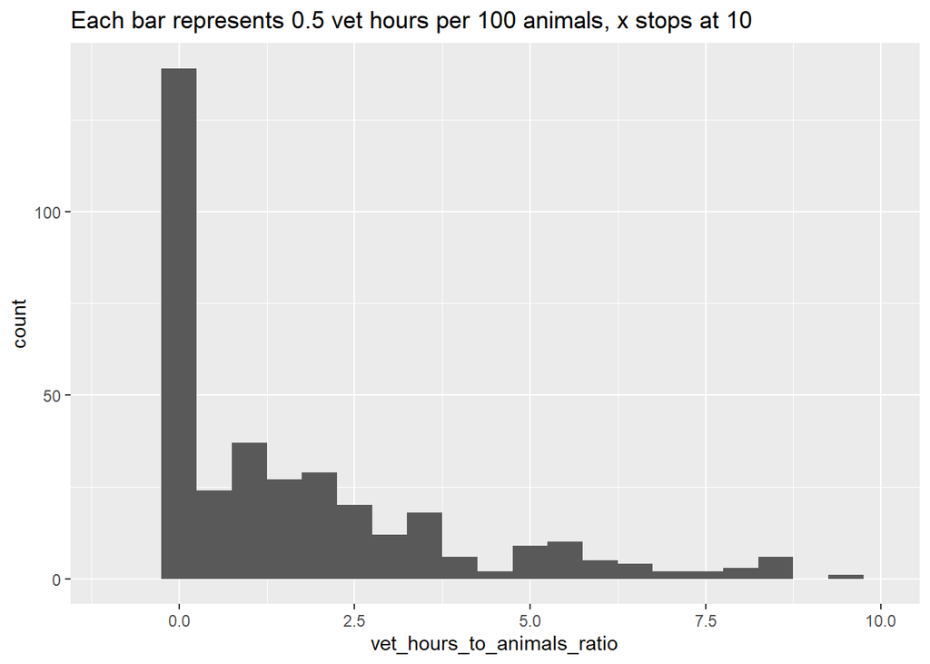

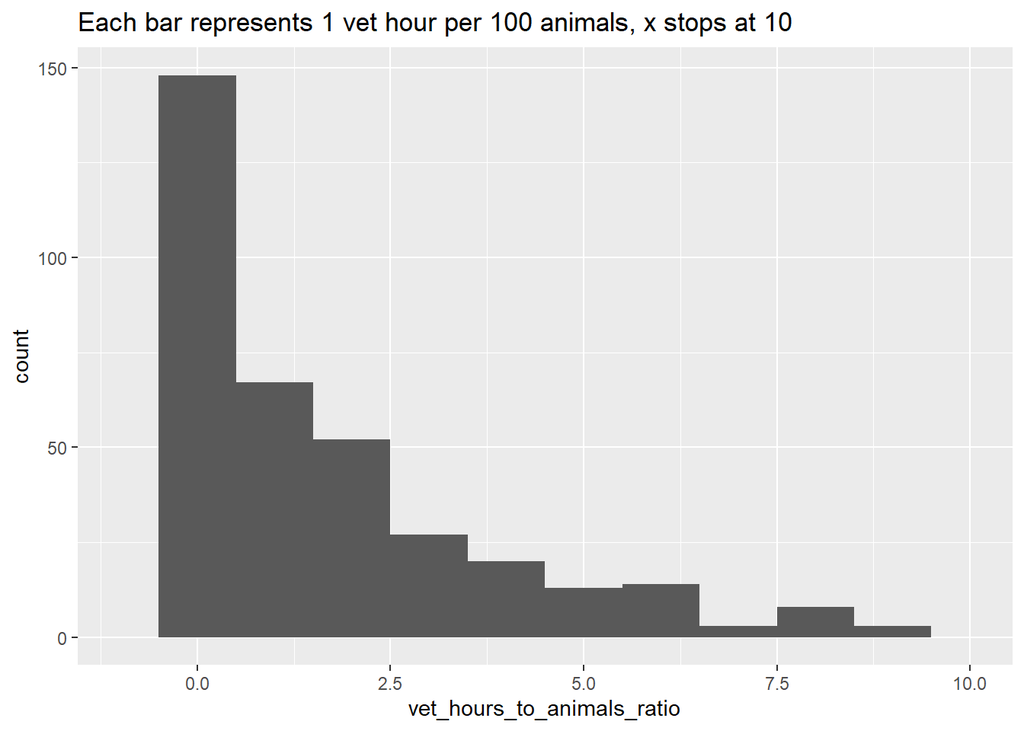

## Org Type

#### Q20 Vet Care Provided

[output not shown]

```
## [1] "Q20_Provides_Spay-Neuter_For_Org_Animals_By_Own_Vet_Staff_Or_From_A_Local_Vet"
```

|  | Q4_Org_Type | Yes | Yes_Pct |
| --- | --- | --- | --- |
| 1 | Brick-and-mortar government animal shelter | 98 | 90.74% |
| 2 | Brick-and-mortar nonprofit animal shelter WITH a government contract for animal control or housing services | 115 | 91.26% |
| 3 | Brick-and-mortar nonprofit animal shelter WITHOUT a government contract for animal control or housing services | 138 | 92.00% |

```
## [1] "Q20_Provides_Spay-Neuter_For_Publicly_Owned_Animals"
```

|  | Q4_Org_Type | Yes | Yes_Pct |
| --- | --- | --- | --- |
| 1 | Brick-and-mortar government animal shelter | 31 | 28.70% |
| 2 | Brick-and-mortar nonprofit animal shelter WITH a government contract for animal control or housing services | 85 | 67.46% |
| 3 | Brick-and-mortar nonprofit animal shelter WITHOUT a government contract for animal control or housing services | 93 | 62.00% |

```
## [1] "Q20_Provides_Owner_Requested_Euthanasia_For_Publicly_Owned_Animals"
```

|  | Q4_Org_Type | Yes | Yes_Pct |
| --- | --- | --- | --- |
| 1 | Brick-and-mortar government animal shelter | 72 | 66.66% |
| 2 | Brick-and-mortar nonprofit animal shelter WITH a government contract for animal control or housing services | 85 | 67.46% |
| 3 | Brick-and-mortar nonprofit animal shelter WITHOUT a government contract for animal control or housing services | 54 | 36.00% |

```
## [1] "Q20_Provides_Vet_Care_For_Our_Org_Animals"
```

|  | Q4_Org_Type | Yes | Yes_Pct |
| --- | --- | --- | --- |
| 1 | Brick-and-mortar government animal shelter | 96 | 88.88% |
| 2 | Brick-and-mortar nonprofit animal shelter WITH a government contract for animal control or housing services | 121 | 96.04% |
| 3 | Brick-and-mortar nonprofit animal shelter WITHOUT a government contract for animal control or housing services | 142 | 94.66% |

```
## [1] "Q20_Provides_Non-Spay/Neuter_Vet_Care_For_Publicly_Owned_Animals"
```

|  | Q4_Org_Type | Yes | Yes_Pct |
| --- | --- | --- | --- |
| 1 | Brick-and-mortar government animal shelter | 19 | 17.60% |
| 2 | Brick-and-mortar nonprofit animal shelter WITH a government contract for animal control or housing services | 63 | 50.00% |
| 3 | Brick-and-mortar nonprofit animal shelter WITHOUT a government contract for animal control or housing services | 78 | 52.00% |

```
## [1] "Q20_Provides_Community_Vaccination_Clinics"
```

|  | Q4_Org_Type | Yes | Yes_Pct |
| --- | --- | --- | --- |
| 1 | Brick-and-mortar government animal shelter | 65 | 60.18% |
| 2 | Brick-and-mortar nonprofit animal shelter WITH a government contract for animal control or housing services | 82 | 65.08% |
| 3 | Brick-and-mortar nonprofit animal shelter WITHOUT a government contract for animal control or housing services | 80 | 53.34% |

```
## [1] "Q20_Provides_Health_Certificates_For_Transport"
```

|  | Q4_Org_Type | Yes | Yes_Pct |
| --- | --- | --- | --- |
| 1 | Brick-and-mortar government animal shelter | 52 | 48.14% |
| 2 | Brick-and-mortar nonprofit animal shelter WITH a government contract for animal control or housing services | 62 | 49.20% |
| 3 | Brick-and-mortar nonprofit animal shelter WITHOUT a government contract for animal control or housing services | 40 | 26.66% |

```
## [1] "Q20_Provides_Necropsies_And/Or_Forensic_Work_For_Law_Enforcement"
```

|  | Q4_Org_Type | Yes | Yes_Pct |
| --- | --- | --- | --- |
| 1 | Brick-and-mortar government animal shelter | 51 | 47.22% |
| 2 | Brick-and-mortar nonprofit animal shelter WITH a government contract for animal control or housing services | 48 | 38.10% |
| 3 | Brick-and-mortar nonprofit animal shelter WITHOUT a government contract for animal control or housing services | 16 | 10.66% |

```
## [1] "Q20_Provides_Specimen_Collection_And_Testing_For_Rabies"
```

|  | Q4_Org_Type | Yes | Yes_Pct |
| --- | --- | --- | --- |
| 1 | Brick-and-mortar government animal shelter | 80 | 74.08% |
| 2 | Brick-and-mortar nonprofit animal shelter WITH a government contract for animal control or housing services | 63 | 50.00% |
| 3 | Brick-and-mortar nonprofit animal shelter WITHOUT a government contract for animal control or housing services | 25 | 16.66% |

## Support Staff Ratio

#### Tables

|  | AAWA_dat$sheltering_region | median | average |
| --- | --- | --- | --- |
| 1 | Atlantic | 1 | 0.8726 |
| 2 | Mid-Northeast | 1 | 0.7911 |
| 3 | Mountain West | 0.9375 | 0.784 |
| 4 | North Central | 0.875 | 0.7115 |
| 5 | North Midwest | 1 | 0.8433 |
| 6 | Northeast | 0.995 | 0.8042 |
| 7 | Pacific | 0.8696 | 0.7752 |
| 8 | South Central | 0.6863 | 0.6004 |
| 9 | South Midwest | 0.8864 | 0.7389 |

|  | AAWA_dat$org_intake_size | median | average |
| --- | --- | --- | --- |
| 1 | 2000-5000 | 1 | 0.7907 |
| 2 | 450-2000 | 1 | 0.7475 |
| 3 | Less than 450 | 1 | 0.8639 |
| 4 | More than 5000 | 0.8673 | 0.7847 |

|  | AAWA_dat$Q4_Org_Type | median | average |
| --- | --- | --- | --- |
| 1 | Brick-and-mortar government animal shelter | 1 | 0.744 |
| 2 | Brick-and-mortar nonprofit animal shelter WITH a government contract for animal control or housing services | 0.8469 | 0.764 |
| 3 | Brick-and-mortar nonprofit animal shelter WITHOUT a government contract for animal control or housing services | 1 | 0.8199 |

#### Histogram

A high ratio generally means the current vet hours is substantially higher than the vet hours looking to fill. A low ratio generally means the opposite

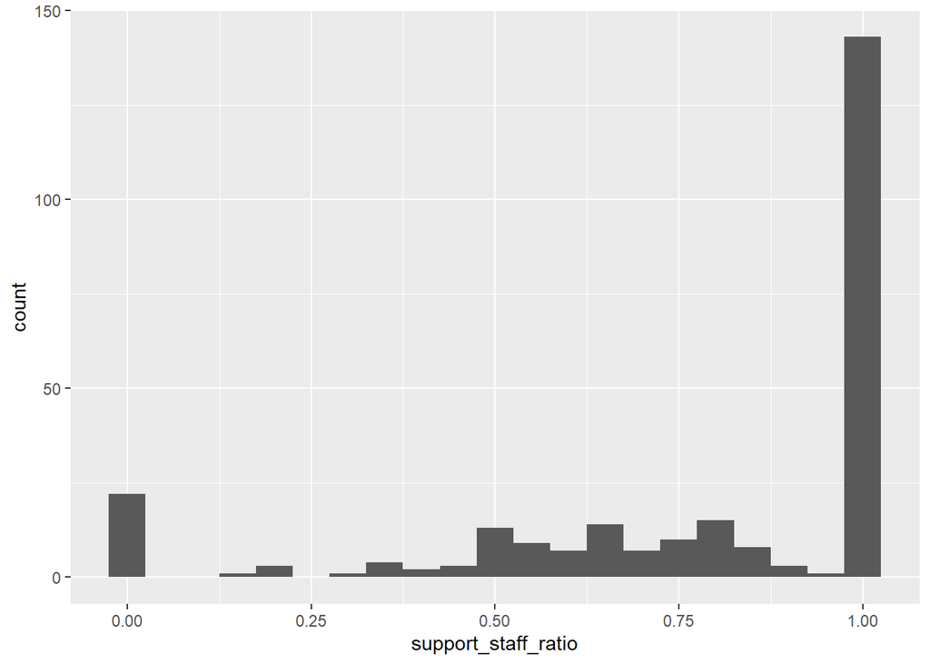